# Gene_anno

Tina Gorsek Sparovec

26.1.22

|  | Row.names | baseMean | log2FoldChange | lfcSE | stat | pvalue | padj | weight | gene_name |
| --- | --- | --- | --- | --- | --- | --- | --- | --- | --- |
| ENSG00000004139 | ENSG00000004139 | 38.1315802 | -1.0701259 | 0.3547129 | -3.016879 | 2.553921e-03 | 3.242892e-02 | 1.63073341 | SARM1 |
| ENSG00000005810 | ENSG00000005810 | 528.5583843 | -0.5045718 | 0.1844151 | -2.736066 | 6.217862e-03 | 4.092980e-02 | 2.79050233 | MYCBP2 |
| ENSG00000006282 | ENSG00000006282 | 96.7133961 | -1.0043747 | 0.3219225 | -3.119927 | 1.808959e-03 | 2.353199e-02 | 1.84768627 | SPATA20 |
| ENSG00000008083 | ENSG00000008083 | 213.3946491 | 1.0331500 | 0.2996781 | 3.447532 | 5.657333e-04 | 1.126369e-02 | 1.71817006 | JARID2 |
| ENSG00000008405 | ENSG00000008405 | 79.3779667 | 1.2373615 | 0.4136519 | 2.991311 | 2.777824e-03 | 3.412100e-02 | 1.63073341 | CRY1 |
| ENSG00000009413 | ENSG00000009413 | 1309.0647155 | -0.8222371 | 0.2554605 | -3.218647 | 1.287970e-03 | 1.349072e-02 | 3.00425477 | REV3L |
| ENSG00000010278 | ENSG00000010278 | 194.0912673 | 1.7454948 | 0.4486568 | 3.890490 | 1.000422e-04 | 3.331198e-03 | 1.78487195 | CD9 |
| ENSG00000010539 | ENSG00000010539 | 46.1118305 | -0.9529577 | 0.2894389 | -3.292431 | 9.932528e-04 | 1.821101e-02 | 1.51297142 | ZNF200 |
| ENSG00000010810 | ENSG00000010810 | 359.4922866 | -1.0563765 | 0.2777994 | -3.802660 | 1.431507e-04 | 3.104138e-03 | 2.79050233 | FYN |
| ENSG00000011260 | ENSG00000011260 | 73.1617892 | 0.8206998 | 0.2438826 | 3.365143 | 7.650388e-04 | 1.436590e-02 | 1.63073341 | UTP18 |

[output cut: 725 more lines]

## TopGO vignette

http://citeseerx.ist.psu.edu/viewdoc/download?doi=10.1.1.515.8324&rep=rep1&type=pdf

```r
data(ALL)
data(geneList)
affyLib <- paste(annotation(ALL), "db", sep = ".")
 library(package = affyLib, character.only = TRUE)
sum(topDiffGenes(geneList))
head(topDiffGenes(geneList))
 sampleGOdata <- new("topGOdata",
                     description = "Simple session", ontology = "BP",
                     allGenes = geneList, geneSel = topDiffGenes,
                     nodeSize = 10,
                     annot = annFUN.db, affyLib = affyLib)
```

# TopGO on the RNAseq results

## Preparing the input vector

The input should be a named vector of DEG genes. Used is ENS_sig object created in 1.0_metadata_exploration. (changed on 11.7.22)

If using sig.res you need to change the code.

```r
up_genes <- ENS_sig |>
  subset(padj < 0.05 & ENS_sig$log2FoldChange > 0) >
  rownames_to_column(var = "gene_id") |>
  pull(gene_id)
```

```
Error in rownames_to_column(var = "gene_id") :
  argument ".data" is missing, with no default
```

```r
#performing an enrichment

resultFisher <- runTest(GOdata_MF, algorithm = "classic", statistic = "fisher")
```

```
             -- Classic Algorithm --

         the algorithm is scoring 149 nontrivial nodes
         parameters:
             test statistic: fisher
```

```r
resultFisher
```

```
Description:
Ontology: MF
'classic' algorithm with the 'fisher' test
149 GO terms scored: 0 terms with p < 0.01
Annotation data:
    Annotated genes: 594
    Significant genes: 594
    Min. no. of genes annotated to a GO: 10
    Nontrivial nodes: 149
```

testing the enrichment using KS test, with classic and elim method

```r
resultKS <- runTest(GOdata_MF, algorithm = "classic", statistic = "ks")
```

```
             -- Classic Algorithm --

         the algorithm is scoring 149 nontrivial nodes
         parameters:
             test statistic: ks
             score order: increasing
```

```r
resultKS.elim <- runTest(GOdata_MF, algorithm = "elim", statistic = "ks", na.rm=T)
```

```
             -- Elim Algorithm --

         the algorithm is scoring 149 nontrivial nodes
         parameters:
             test statistic: ks
             cutOff: 0.01
             score order: increasing

     Level 10:  1 nodes to be scored    (0 eliminated genes)

     Level 9:   4 nodes to be scored    (0 eliminated genes)

     Level 8:   4 nodes to be scored    (0 eliminated genes)

     Level 7:   12 nodes to be scored   (0 eliminated genes)

     Level 6:   21 nodes to be scored   (0 eliminated genes)

     Level 5:   35 nodes to be scored   (0 eliminated genes)

     Level 4:   37 nodes to be scored   (0 eliminated genes)

     Level 3:   25 nodes to be scored   (0 eliminated genes)

     Level 2:   9 nodes to be scored    (0 eliminated genes)

     Level 1:   1 nodes to be scored    (0 eliminated genes)
```

```r
##### error not enough y data
## could be the problem with NA in ENS_sig

#### Solution in other vignette (link below), to get the elim results
test.stat <- new("elimCount", testStatistic = GOFisherTest,
                 name = "Fisher test", cutOff = 0.01)
resultElim <- getSigGroups(GOdata_MF, test.stat)
```

```
             -- Elim Algorithm --

         the algorithm is scoring 149 nontrivial nodes
         parameters:
             test statistic: Fisher test
             cutOff: 0.01

     Level 10:  1 nodes to be scored    (0 eliminated genes)

     Level 9:   4 nodes to be scored    (0 eliminated genes)

     Level 8:   4 nodes to be scored    (0 eliminated genes)

     Level 7:   12 nodes to be scored   (0 eliminated genes)

     Level 6:   21 nodes to be scored   (0 eliminated genes)

     Level 5:   35 nodes to be scored   (0 eliminated genes)

     Level 4:   37 nodes to be scored   (0 eliminated genes)

     Level 3:   25 nodes to be scored   (0 eliminated genes)

     Level 2:   9 nodes to be scored    (0 eliminated genes)

     Level 1:   1 nodes to be scored    (0 eliminated genes)
```

```r
#http://compdiag.molgen.mpg.de/ngfn/docs/2007/sep/topGO_Exercises.pdf
```

## Analysis of results

analysis of most sig. GO terms and coresponding p-val GenTable() returns a df containing topnodes GO term, for assessing the GO’s term pval- score() http://citeseerx.ist.psu.edu/viewdoc/download?doi=10.1.1.515.8324&rep=rep1&type=pdf

The elim method was design to be more conservative then the classic method and therefore one expects the p-values returned by the former method are lower bounded by the p-values returned by the later method

```r
allRes <- GenTable(GOdata_MF,
                  classicFisher = resultFisher,
                  classicKS = resultKS,
                  elimKS = resultElim, #with elim method from the second elim calculation (see solution)
                  orderBy = "elimKS", ranksOf = "classicFisher", topNodes = 50) # go for all of them and select what you want
allRes #depends on the threshold that you use
```

|  | GO.ID | Term | Annotated | Significant | Expected | Rank in classicFisher | classicFisher | classicKS | elimKS |
| --- | --- | --- | --- | --- | --- | --- | --- | --- | --- |
| 1 | GO:0000166 | nucleotide binding | 83 | 83 | 83 | 1 | 1 | 0.791 | 1 |
| 2 | GO:0000287 | magnesium ion binding | 10 | 10 | 10 | 2 | 1 | 0.331 | 1 |
| 3 | GO:0000976 | transcription cis-regulatory region bind... | 57 | 57 | 57 | 3 | 1 | 0.661 | 1 |
| 4 | GO:0000977 | RNA polymerase II transcription regulato... | 51 | 51 | 51 | 4 | 1 | 0.647 | 1 |
| 5 | GO:0000978 | RNA polymerase II cis-regulatory region ... | 46 | 46 | 46 | 5 | 1 | 0.720 | 1 |
| 6 | GO:0000981 | DNA-binding transcription factor activit... | 49 | 49 | 49 | 6 | 1 | 0.758 | 1 |
| 7 | GO:0000987 | cis-regulatory region sequence-specific ... | 48 | 48 | 48 | 7 | 1 | 0.689 | 1 |
| 8 | GO:0001067 | transcription regulatory region nucleic ... | 57 | 57 | 57 | 8 | 1 | 0.661 | 1 |
| 9 | GO:0001216 | DNA-binding transcription activator acti... | 17 | 17 | 17 | 9 | 1 | 0.970 | 1 |
| 10 | GO:0001217 | DNA-binding transcription repressor acti... | 18 | 18 | 18 | 10 | 1 | 0.139 | 1 |

[output cut: 40 more lines]

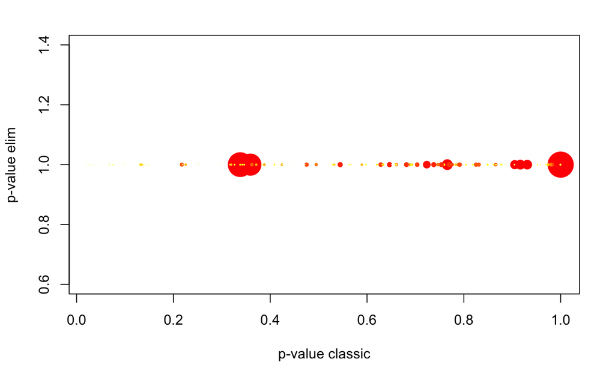

```r
#### Result is a topNodes GO terms identified by the elim algorithm


## Accessing p-values from the GO object
 pValue.classic <- score(resultKS)
 pValue.elim <- score(resultElim)[names(pValue.classic)]
 gstat <- termStat(GOdata_MF, names(pValue.classic))
 gSize <- gstat$Annotated / max(gstat$Annotated) * 4
 colMap <- function(x) {
  .col <- rep(rev(heat.colors(length(unique(x)))), time = table(x))
  return(.col[match(1:length(x), order(x))])
 }

 gCol <- colMap(gstat$Significant)
plot(pValue.classic, pValue.elim, xlab = "p-value classic", ylab = "p-value elim",
      pch = 19, cex = gSize, col = gCol)
```

```r
 write.csv(allRes, "GOterms.csv")
```

```r
sel.go <- names(pValue.classic)[pValue.elim < pValue.classic]
 cbind(termStat(GOdata_MF, sel.go),
elim = pValue.elim[sel.go],
classic = pValue.classic[sel.go])
```

| Annotated | Significant | Expected | elim | classic |
| --- | --- | --- | --- | --- |

references for comparison with PAS: https://www.frontiersin.org/articles/10.3389/fgene.2020.551495/full

```
$dag
A graphNEL graph with directed edges
Number of Nodes = 21
Number of Edges = 26

$complete.dag
[1] "A graph with 21 nodes."
```

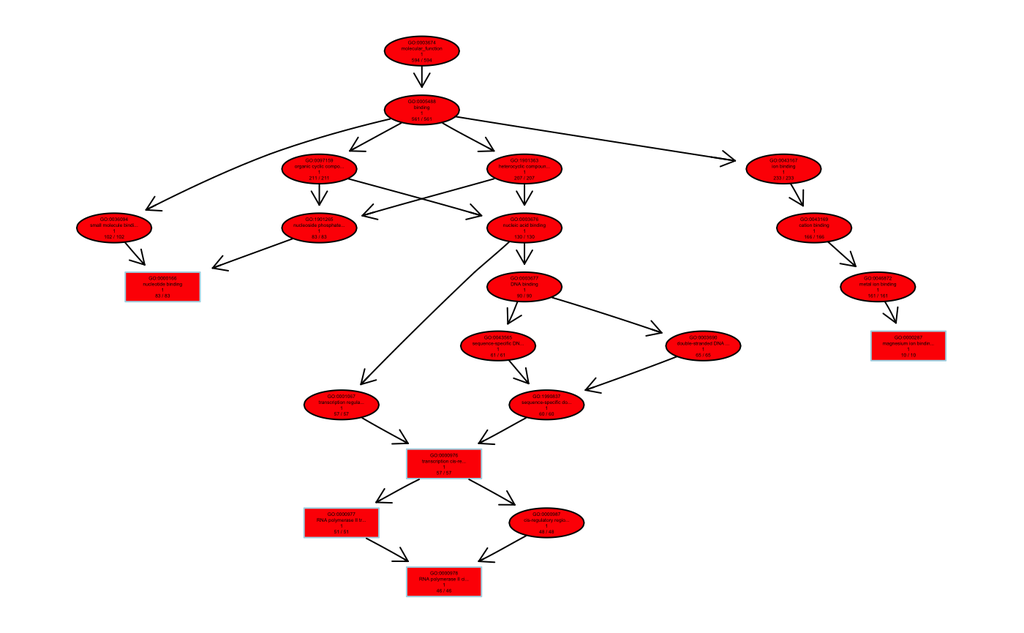

```r
showSigOfNodes(GOdata_MF, score(resultFisher), firstSigNodes = 5, useInfo = 'all')
```

## How significant GO terms are distributed over GO graph

```r
sel.go <- names(pValue.classic)[pValue.elim < pValue.classic]
 cbind(termStat(GOdata_MF, sel.go),
       elim = pValue.elim[sel.go],
       classic = pValue.classic[sel.go])
 pdf("plotGO.pdf")
 showSigOfNodes(GOdata_MF, score(resultElim), firstSigNodes = 5, useInfo = 'all')
 dev.off()
```

## Annotation

nr. 5) in the vignete

```r
BPterms <- ls(GOBPTerm)
head(BPterms)
```

```
[1] "GO:0000001" "GO:0000002" "GO:0000003" "GO:0000011" "GO:0000012" "GO:0000017"
```

```r
 a <- genes(GOdata_MF) ## obtain the list of genes
 head(a)
```

```
[1] "SARM1"  "MYCBP2" "JARID2" "CRY1"   "REV3L"  "CD9"
```

```r
 numGenes(GOdata_MF)
```

```
[1] 594
```

```r
 ### Error in (function (classes, fdef, mtable)  :
  #unable to find an inherited method for function 'genes' for signature '"topGOdata"'

 a<-GOdata_MF@allGenes
 head(a)
```

```
[1] "SARM1"   "MYCBP2"  "SPATA20" "JARID2"  "CRY1"    "REV3L"
```

```r
 # retrieving a score of specified set of genes
selGenes <- sample(a, 10)
 gs <- geneScore(GOdata_MF, whichGenes = selGenes)
 print(gs)
```

```
      BCAR3        CD63       SGPP1       EPHA3         CRH        NET1
0.006754635 0.035487948 0.011779232 0.041953464 0.048553962 0.012596720
```

```r
 # unnamed vector or the scrore of all genes
 gs<-geneScore(GOdata_MF, whichGenes = selGenes, use.names=F)
 print(gs)
```

```
[1] 0.006754635 0.035487948 0.011779232 0.041953464 0.048553962 0.012596720
```

```r
 gs <- geneScore(GOdata_MF, use.names = FALSE)
 str(gs)
```

```
 num [1:594] 0.0324 0.0409 0.0113 0.0341 0.0135 ...
```

```r
#list of sig. genes
 sg <- sigGenes(GOdata_MF)
str(sg)
```

```
 chr [1:594] "SARM1" "MYCBP2" "JARID2" "CRY1" "REV3L" "CD9" "ZNF200" "FYN" "UTP18" "DCN" "SEMA3B" "GPRC5A" ...
```

```r
numSigGenes(GOdata_MF)
```

```
[1] 594
```

```r
# updating the genes
.geneList <- geneScore(GOdata_MF, use.names = TRUE)
 GOdata_MF ## more available genes
```

```
------------------------- topGOdata object -------------------------

 Description:
   -

 Ontology:
   -  MF

 735 available genes (all genes from the array):
   - symbol:  SARM1 MYCBP2 SPATA20 JARID2 CRY1  ...
   - score :  0.0324 0.04093 0.023532 0.01126 0.034  ...
   - 735  significant genes.

 594 feasible genes (genes that can be used in the analysis):
   - symbol:  SARM1 MYCBP2 JARID2 CRY1 REV3L  ...
   - score :  0.0324 0.04093 0.01126 0.034 0.0135  ...
   - 594  significant genes.

 GO graph (nodes with at least  10  genes):
   - a graph with directed edges
   - number of nodes = 149
   - number of edges = 175

------------------------- topGOdata object -------------------------
```

```r
 GOdata_MF <- updateGenes(GOdata_MF, .geneList, topDiffGenes)
 GOdata_MF ## the available genes are now the feasible genes
```

```
------------------------- topGOdata object -------------------------

 Description:
   -

 Ontology:
   -  MF

 594 available genes (all genes from the array):
   - symbol:  SARM1 MYCBP2 JARID2 CRY1 REV3L  ...
   - score :  0.0324 0.04093 0.01126 0.034 0.0135  ...
   - 233  significant genes.

 594 feasible genes (genes that can be used in the analysis):
   - symbol:  SARM1 MYCBP2 JARID2 CRY1 REV3L  ...
   - score :  0.0324 0.04093 0.01126 0.034 0.0135  ...
   - 233  significant genes.

 GO graph (nodes with at least  10  genes):
   - a graph with directed edges
   - number of nodes = 149
   - number of edges = 175

------------------------- topGOdata object -------------------------
```

```r
 graph(GOdata_MF)                                              # ???is this number of nods7edges enough????
```

```
A graphNEL graph with directed edges
Number of Nodes = 149
Number of Edges = 175
```

```r
ug <- usedGO(GOdata_MF)
 head(ug)
```

```
[1] "GO:0000166" "GO:0000287" "GO:0000976" "GO:0000977" "GO:0000978" "GO:0000981"
```

```r
 sel.terms <- sample(usedGO(GOdata_MF), 10) #selecting 10 random GO terms to get the genes
num.ann.genes <- countGenesInTerm(GOdata_MF, sel.terms) ## the number of annotated genes > num.ann.genes
 ann.genes <- genesInTerm(GOdata_MF, sel.terms) ## get the annotations
 head(ann.genes)
```

```
$`GO:0004674`
 [1] "ACVR1C" "ALPK3"  "CDK17"  "KALRN"  "LTBP1"  "MAP3K8" "NRBP2"  "NUAK2"  "PAK2"   "PHKA2"  "PLK3"
[12] "PTK2B"  "SIK1"   "TAOK2"  "TGFBR3" "TTN"    "ULK4"   "WNK2"

$`GO:0022804`
 [1] "ABCA6"   "ABCA9"   "ABCB8"   "COX5A"   "RALBP1"  "SLC17A4" "SLC1A5"  "SLC1A6"  "SLC35E3" "SLC38A1"
[11] "SLC4A7"  "SLC7A5"  "SLCO3A1"

$`GO:0001067`
 [1] "ATOH8"  "CEBPB"  "CEBPD"  "CRY1"   "ELF4"   "ELL"    "ESR2"   "ETS2"   "FOS"    "FOSB"   "FOXJ3"
[12] "FOXO4"  "GLIS3"  "H3-3B"  "HOXA3"  "HOXD9"  "JDP2"   "KDM5A"  "KLF12"  "LITAF"  "MXD1"   "NFE2L1"
[23] "NFE2L3" "NR1H3"  "NR2F1"  "NR2F2"  "NRIP1"  "PEG3"   "PITX2"  "RBPJ"   "RPS3"   "RPTOR"  "SKIL"
[34] "SMAD3"  "SNAI1"  "TBL1X"  "TFAM"   "TGIF1"  "THRB"   "WT1"    "XBP1"   "ZBED3"  "ZBTB10" "ZBTB7A"
[45] "ZFP30"  "ZNF10"  "ZNF197" "ZNF208" "ZNF26"  "ZNF281" "ZNF37A" "ZNF395" "ZNF493" "ZNF563" "ZNF727"
[56] "ZNF829" "ZNF883"
```

[output cut: 29 more lines]

```r
 #sel.term missing== you get all the GO terms
 ann.score <- scoresInTerm(GOdata_MF, sel.terms)
 head(ann.score)
```

```
$`GO:0004674`
 [1] 2.125338e-02 4.221791e-02 1.088814e-02 4.431370e-03 1.138364e-02 1.488308e-02 4.704687e-03 1.855985e-05
 [9] 2.015380e-03 2.744144e-02 2.899009e-02 2.296806e-02 3.077335e-03 2.640263e-02 4.446580e-02 5.303606e-04
[17] 1.973870e-02 1.166557e-02

$`GO:0022804`
 [1] 0.0411328260 0.0447979679 0.0134907193 0.0304482637 0.0053062945 0.0063703768 0.0038981436 0.0055010409
 [9] 0.0067228288 0.0120199724 0.0125967196 0.0008372135 0.0021937854

$`GO:0001067`
 [1] 3.934277e-04 8.277322e-04 8.226171e-03 3.412100e-02 3.399866e-02 2.301963e-07 3.696675e-02 8.311041e-04
 [9] 1.034089e-02 4.268822e-02 6.261487e-03 3.650519e-02 4.287314e-02 1.058694e-02 4.113283e-02 6.714224e-03
[17] 3.737575e-02 4.240831e-02 8.803830e-03 3.478824e-02 1.740324e-08 1.569127e-03 3.862581e-03 2.924600e-02
[25] 2.496018e-02 6.706405e-03 1.400375e-03 4.978320e-06 5.303606e-04 2.086718e-02 4.990997e-02 4.997176e-03
[33] 9.408851e-03 2.106758e-02 2.156645e-02 4.680527e-02 3.071596e-02 9.209558e-03 2.577696e-02 8.217883e-04
```

[output cut: 33 more lines]

```r
 ann.score <- scoresInTerm(GOdata_MF, sel.terms, use.names = TRUE)
 head(ann.score)
```

```
$`GO:0004674`
      ACVR1C        ALPK3        CDK17        KALRN        LTBP1       MAP3K8        NRBP2        NUAK2
2.125338e-02 4.221791e-02 1.088814e-02 4.431370e-03 1.138364e-02 1.488308e-02 4.704687e-03 1.855985e-05
        PAK2        PHKA2         PLK3        PTK2B         SIK1        TAOK2       TGFBR3          TTN
2.015380e-03 2.744144e-02 2.899009e-02 2.296806e-02 3.077335e-03 2.640263e-02 4.446580e-02 5.303606e-04
        ULK4         WNK2
1.973870e-02 1.166557e-02

$`GO:0022804`
       ABCA6        ABCA9        ABCB8        COX5A       RALBP1      SLC17A4       SLC1A5       SLC1A6
0.0411328260 0.0447979679 0.0134907193 0.0304482637 0.0053062945 0.0063703768 0.0038981436 0.0055010409
     SLC35E3      SLC38A1       SLC4A7       SLC7A5      SLCO3A1
0.0067228288 0.0120199724 0.0125967196 0.0008372135 0.0021937854

$`GO:0001067`
       ATOH8        CEBPB        CEBPD         CRY1         ELF4          ELL         ESR2         ETS2
3.934277e-04 8.277322e-04 8.226171e-03 3.412100e-02 3.399866e-02 2.301963e-07 3.696675e-02 8.311041e-04
         FOS         FOSB        FOXJ3        FOXO4        GLIS3        H3-3B        HOXA3        HOXD9
1.034089e-02 4.268822e-02 6.261487e-03 3.650519e-02 4.287314e-02 1.058694e-02 4.113283e-02 6.714224e-03
        JDP2        KDM5A        KLF12        LITAF         MXD1       NFE2L1       NFE2L3        NR1H3
3.737575e-02 4.240831e-02 8.803830e-03 3.478824e-02 1.740324e-08 1.569127e-03 3.862581e-03 2.924600e-02
       NR2F1        NR2F2        NRIP1         PEG3        PITX2         RBPJ         RPS3        RPTOR
2.496018e-02 6.706405e-03 1.400375e-03 4.978320e-06 5.303606e-04 2.086718e-02 4.990997e-02 4.997176e-03
        SKIL        SMAD3        SNAI1        TBL1X         TFAM        TGIF1         THRB          WT1
9.408851e-03 2.106758e-02 2.156645e-02 4.680527e-02 3.071596e-02 9.209558e-03 2.577696e-02 8.217883e-04
        XBP1        ZBED3       ZBTB10       ZBTB7A        ZFP30        ZNF10       ZNF197       ZNF208
3.280437e-02 2.192758e-02 1.438467e-04 3.265262e-02 1.166557e-02 2.438203e-03 4.990997e-02 3.364913e-02
       ZNF26       ZNF281       ZNF37A       ZNF395       ZNF493       ZNF563       ZNF727       ZNF829
1.520439e-02 1.993939e-02 1.555548e-02 8.643227e-03 2.075749e-02 4.477176e-02 1.747964e-02 1.948739e-03
      ZNF883
1.711217e-02

$`GO:0031406`
       ACACB      ALOX5AP      CASTOR1       CRABP2        EGLN3        EPDR1        NR2F2        P4HA1
4.400971e-02 1.645023e-02 2.086718e-02 1.342873e-02 6.355234e-05 4.496359e-02 6.706405e-03 1.115770e-04
       P4HA3         PSAP     SERPINA5      SIGLEC6
2.562135e-02 1.656401e-02 3.044488e-02 3.331063e-06

$`GO:0003676`
       ANXA2        ATOH8        CEBPB        CEBPD         CHD9         CRY1          DCN        DCP1B
```

[output cut: 30 more lines]

```
3.364913e-02 1.520439e-02 1.993939e-02 1.555548e-02 8.643227e-03 2.075749e-02 4.477176e-02 1.747964e-02
      ZNF829       ZNF883
1.948739e-03 1.711217e-02

$`GO:0046983`
        ADRA2C           AOX1 ARMCX5-GPRASP2          ATOH8          CADM1          CADM3          CEBPB
  7.397875e-03   1.348318e-02   2.530220e-02   3.934277e-04   2.192758e-02   2.884285e-03   8.277322e-04
          FMR1           GBP1           GBP2           H2AJ          H3-3B          HARS1       HSP90AA1
  3.447529e-03   2.043924e-02   3.379912e-02   4.314519e-02   1.058694e-02   2.967770e-02   2.144108e-02
           ID4          IMPA2           JDP2         MAN2A1           MXD1          NR2F2          NTRK1
  1.166557e-02   3.207056e-02   3.737575e-02   1.877181e-02   1.740324e-08   6.706405e-03   6.289654e-05
      PAFAH1B2          PDCD6         PEX11A         PGRMC1           PSAP      RAB11FIP3          RRAGC
  4.796945e-02   3.514091e-02   2.112096e-02   9.910480e-03   1.656401e-02   4.607157e-02   8.226171e-03
       S100A16          SMAD3          STUB1            TDG          TENM3          TGFB2           XBP1
  2.967770e-02   2.106758e-02   1.989322e-02   2.516686e-02   9.501284e-03   3.412100e-02   3.280437e-02
```

```r
 termStat(GOdata_MF, sel.terms)
```

|  | Annotated | Significant | Expected |
| --- | --- | --- | --- |
| GO:0004674 | 18 | 6 | 7.06 |
| GO:0022804 | 13 | 7 | 5.10 |
| GO:0001067 | 57 | 23 | 22.36 |
| GO:0031406 | 12 | 4 | 4.71 |
| GO:0003676 | 130 | 45 | 50.99 |
| GO:0046983 | 35 | 11 | 13.73 |
| GO:0044389 | 12 | 4 | 4.71 |
| GO:0008289 | 31 | 7 | 12.16 |
| GO:0032555 | 77 | 26 | 30.20 |
| GO:0030246 | 14 | 7 | 5.49 |

```r
goID <- allRes[10, "GO.ID"]
gt <- printGenes(GOdata_MF, whichTerms = goID, chip = affyLib, numChar = 40)
```

```
Error in h(simpleError(msg, call)) :
  error in evaluating the argument 'X' in selecting a method for function 'sapply': value for "MXD1" not found
```

To do:

We cont with likelihood ratio test, ~ for the model use also other factors that influence- you need even number of comparison (6=6) variance partition package https://rdrr.io/bioc/variancePartition/f/inst/doc/variancePartition.pdf

doing heatmap using the genes (done)

age clust by similarity

- topGOtable
- pathways and functions - make a table

#topgotable –> 4.0_pcaExplore_GO rmd.

```r
ENS_res<- merge(as.data.frame(res), KEY, by.y="gene_name", by.x= "row.names")
ENS_res$gene_id<-gsub("\\..*","",ENS_res$gene_id)
genenames_GO<-mapIds(org.Hs.eg.db,
                     keys=ENS_res$gene_id,
                     column = "SYMBOL",
                     keytype = "ENSEMBL")
annotation_GO <- data.frame(gene_name = genenames_GO, #some duplication
                                row.names = rownames(ENS_res),
                                stringsAsFactors = FALSE)
head(annotation_GO)
```

|  | gene_name |
| --- | --- |
| 1 | LOC102724250 |
| 2 | NA |
| 3 | NA |
| 4 | NA |
| 5 | LOC389831 |
| 6 | LOC107987373 |

```r
anno_df_orgdb <- get_annotation_orgdb(dds = dds_GO,
                                      orgdb_species = "org.Hs.eg.db",
                                      idtype = "ENSEMBL")
anno_df_biomart <- get_annotation(dds = dds,
                                  biomart_dataset = "hsapiens_gene_ensembl",
                                  idtype = "ensembl_gene_id")
res$symbol<- mapIds(org.Hs.eg.db,
                            keys= row.names(res),
                            column="SYMBOL",
                            keytype="ENSEMBL",
                            multiVals="first")
res$entrez <- mapIds(org.Hs.eg.db, ##problem
                            keys=row.names(res),
                            column="ENTREZID",
                            keytype="ENSEMBL",
                            multiVals="first")
resOrdered <- as.data.frame(res[order(res$padj),])
head(resOrdered)
```

|  | baseMean | log2FoldChange | lfcSE | stat | pvalue | padj | symbol | entrez |
| --- | --- | --- | --- | --- | --- | --- | --- | --- |
| ENSG00000120645 | 11.74459 | 15.104725 | 1.9210177 | 7.862877 | 3.754109e-15 | 6.387992e-11 | IQSEC3 | 440073 |
| ENSG00000105825 | 224.29354 | 3.340329 | 0.4347893 | 7.682639 | 1.558446e-14 | 8.839505e-11 | TFPI2 | 7980 |
| ENSG00000134107 | 216.27807 | 2.671869 | 0.3467273 | 7.705964 | 1.298587e-14 | 8.839505e-11 | BHLHE40 | 8553 |
| ENSG00000166106 | 82.08300 | -2.198143 | 0.2890996 | -7.603411 | 2.884263e-14 | 1.226966e-10 | ADAMTS15 | 170689 |
| ENSG00000070669 | 20.34027 | -5.409063 | 0.7913259 | -6.835443 | 8.175185e-12 | 2.318483e-08 | ASNS | 440 |
| ENSG00000090104 | 166.46965 | 3.664822 | 0.5354594 | 6.844258 | 7.687321e-12 | 2.318483e-08 | RGS1 | 5996 |

```r
de_df <- resOrdered[resOrdered$padj < .05 & !is.na(resOrdered$padj),]
de_symbols <- de_df$symbol
# extract background genes
bg_ids <- rownames(dds_GO)[rowSums(counts(dds_GO)) > 0]
bg_symbols <- mapIds(org.Hs.eg.db,
                     keys=bg_ids,
                     column="SYMBOL",
                     keytype="ENSEMBL",
                     multiVals="first")
# run the function
topgoDE_GO <- topGOtable(de_symbols, bg_symbols,
                             ontology = "BP",
                             mapping = "org.Hs.eg.db",
                             geneID = "symbol")
```

[output not shown]